# Ant-following birds: Statistical analysis

Promedio e intervalo creible de 95% de area para las aves que siguen hormigas de manera obligada

```r
mean (b_obligada_a$esperado)
```

```
[1] 3719.851
```

```r
quantile (b_obligada_a$esperado, probs = c(0.025, 0.975))
```

```
    2.5%    97.5%
1523.115 6015.752
```

Promedio e intervalo creible de 95% de $B_f$

```r
mean (b_facultativa_a$esperado)
```

```
[1] 6612.99
```

```r
quantile (b_facultativa_a$esperado, probs = c(0.025, 0.975))
```

```
    2.5%    97.5%
4439.526 8827.137
```

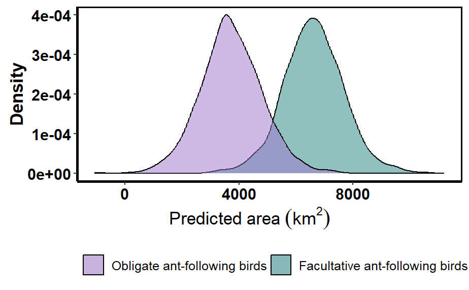

```r
ggplot2.density (data= b_a, xName = "esperado", groupName = "Interaccion_2",
                 alpha=0.5, fillGroupDensity = T,  xtitle = expression(~Predicted~area~(km^{2})), ytitle=   "Density", groupColors=c('#218380', "#9D75CB"))+
guides(fill = guide_legend(reverse = TRUE))+
theme(legend.position = "bottom", legend.title=element_blank(), axis.line = element_line(linewidth =1, colour="black"),
        #axis.text.x = element_blank(),
        axis.line.y.left = element_line(linewidth = 0.8, colour = "black"),
        panel.background = element_rect(fill = "white"),
        #strip.background = element_rect(colour = "white", fill = "white"),
        #strip.text = element_text(size = 18),
        axis.text=element_text(size=18),
        axis.title=element_text(size=18,face="bold"),
        legend.text=element_text(size=10),
        panel.border = element_rect(colour = "black", fill=NA, size=1),
        plot.title = element_text(hjust = 0.5, size= 18)
  )
```

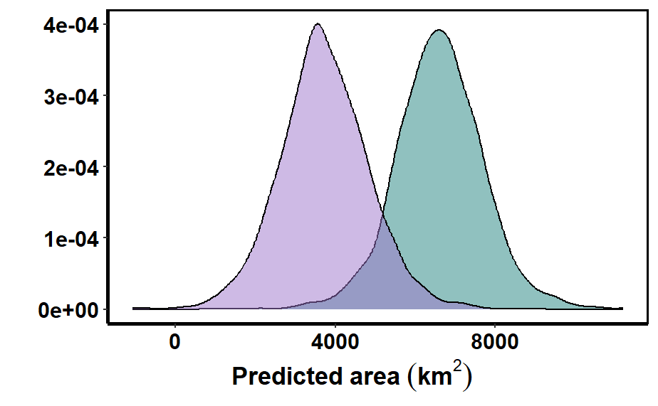

```r
area_aves<- ggplot2.density (data= b_a, xName = "esperado", groupName = "Interaccion_2",
                 alpha=0.5, fillGroupDensity = T,  xtitle = expression(bold(~Predicted~area~(km^{2}))), ytitle=  "", groupColors=c('#218380', "#9D75CB"))+
guides(fill = guide_legend(reverse = TRUE))+
theme(legend.position = "none", legend.title=element_blank(), axis.line = element_line(linewidth =1, colour="black"),
       # axis.text.x = element_blank(),
        axis.line.y.left = element_line(linewidth = 0.8, colour = "black"),
        panel.background = element_rect(fill = "white"),
        #strip.background = element_rect(colour = "white", fill = "white"),
        #strip.text = element_text(size = 18),
        axis.title=element_text(size=18, face="bold"),
        legend.text=element_text(size=10),
        panel.border = element_rect(colour = "black", fill=NA, size=1),
        plot.title = element_text(hjust = 0.5, size= 18)
  )
area_aves
```

El efecto marginal de la intensidad de la interacción es en promedio de -2919 km (resta entre las areas estimadas de aves obligadas - facultativas), sin embargo su intervalo va de -6295 a 248 $km^2$. Lo que nos confirma que hay una tendencia a menores áreas de distribución cuando la intensidad de la interacción es obligada que cuando es facultativa.

```r
emmeans(brms_area, ~ Int,
        regrid = "response") %>%
  contrast(method = "revpairwise")
```

```
 contrast               estimate lower.HPD upper.HPD
 Obligada - Facultativa    -2919     -6295       248

Point estimate displayed: median
HPD interval probability: 0.95
```

Observamos graficamente el intervalo del efecto marginal de la intensidad de la interacción.

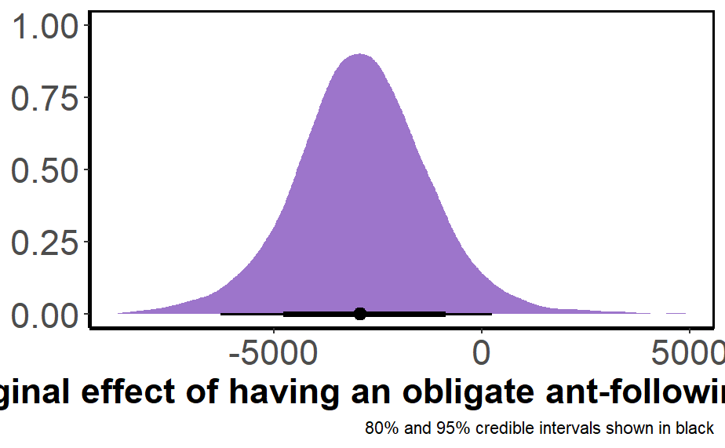

```r
marginal_effects_a <- as.data.frame( b_a$esperado[b_a$Interaccion == "Obligate"] - b_a$esperado[b_a$Interaccion=="Facultative"])
colnames(marginal_effects_a) <- c("Marginal")

ggplot(marginal_effects_a, aes(x = Marginal)) +
  stat_halfeye(.width = c(0.8, 0.95), point_interval = "median_hdi",
               fill = "#9d75cb") +
  labs(x = "Average marginal effect of having an obligate ant-following bird interaction",
       y = NULL, caption = "80% and 95% credible intervals shown in black") +
 theme(legend.position = "None", legend.title=element_blank(), axis.line = element_line(linewidth =1, colour="black"),
        #axis.text.x = element_blank(),
        axis.line.y.left = element_line(linewidth = 0.8, colour = "black"),
        panel.background = element_rect(fill = "white"),
        #strip.background = element_rect(colour = "white", fill = "white"),
        #strip.text = element_text(size = 18),
        axis.text=element_text(size=18),
        axis.title=element_text(size=18,face="bold"),
        legend.text=element_text(size=14),
        panel.border = element_rect(colour = "black", fill=NA, size=1),
        plot.title = element_text(hjust = 0.5, size= 18)
  )
```

```r
NA
NA
```

Figuras

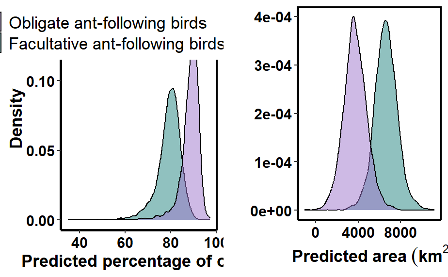

```r
plot_grid(traslape_aves, area_aves, greedy = T)
```